# Week 4 Homework

Author

Andrew Joyce

Published

February 3, 2023

## Setup

```r
library(tidyverse)
library(ggplot2)
library(gridExtra)
library(modelsummary)
library(gt)
theme_set(theme_light(base_family = "Baskerville"))
```

## Exercise 4.1

### 4.1.0 Setup

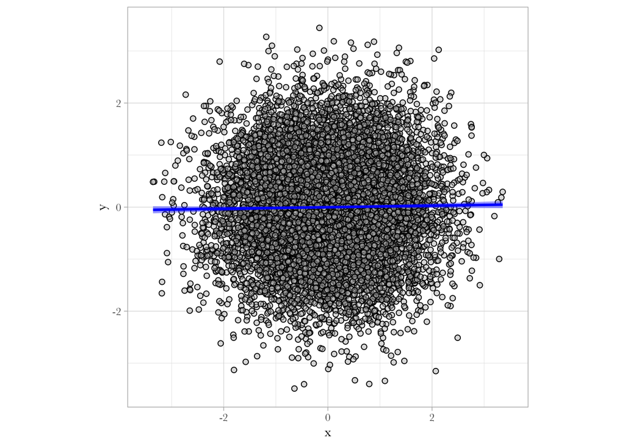

```r
set.seed(12345)

N <- 1e4

d <- tibble(
  x = rnorm(N, 0, 1),
  y = rnorm(N, 0, 1)
)


ggplot(data = d, aes(x, y)) +
  geom_point(shape = "circle filled",
             size = 1.75,
             color="black",
             fill= alpha("grey", 0.5)) +
  coord_fixed() + xlim(-3.5, 3.5) + ylim(-3.5, 3.5) +
  geom_smooth(method = "lm", color = "blue", fill=alpha("blue", 0.25))
```

### 4.1.1 Plot 1

```r
d <- d |>
  mutate(z1 = if_else(x > 0 | y > 0, TRUE, FALSE))

plot1 <- ggplot(data = d, aes(x, y, fill= z1)) +
          geom_point(shape = "circle filled",
                      size = 1.75,
                     color = "black") +
          scale_fill_manual(values = c(alpha("white", 0.75),
                                       alpha("darkgrey", 0.5))) +
         coord_fixed() + xlim(-3.5, 3.5) + ylim(-3.5, 3.5) +
          geom_smooth(data = d |>
                        filter(z1 == TRUE),
                               method = "lm",
                               color = "blue",
                               fill=alpha("blue", 0.25))
```

### 4.1.2 Plot 2

```r
d <- d |>
  mutate(z2 = if_else(y >= -x, TRUE, FALSE))


plot2 <- ggplot(data = d, aes(x, y, fill= z2)) +
          geom_point(shape = "circle filled",
                      size = 1.75,
                     color = "black") +
          scale_fill_manual(values = c(alpha("white", 0.75),
                                       alpha("darkgrey", 0.5))) +
         coord_fixed() + xlim(-3.5, 3.5) + ylim(-3.5, 3.5) +
          geom_smooth(data = d |>
                        filter(z2 == TRUE),
                               method = "lm",
                               color = "blue",
                               fill=alpha("blue", 0.25))
```

### 4.1.3 Plot 3

```r
d <- d |>
  mutate(z3 = if_else( y >= -x - 1.5 & y < -x + 1.5, TRUE, FALSE))

plot3 <- ggplot(data = d, aes(x, y, fill= z3)) +
          geom_point(shape = "circle filled",
                      size = 1.75,
                     color = "black") +
          scale_fill_manual(values = c(alpha("white", 0.75),
                                       alpha("darkgrey", 0.5))) +
         coord_fixed() + xlim(-3.5, 3.5) + ylim(-3.5, 3.5) +
          geom_smooth(data = d |>
                        filter(z3 == TRUE),
                               method = "lm",
                               color = "blue",
                               fill=alpha("blue", 0.25))
```

### 4.1.4 Plot 4

*Special thanks to Shuyi for helping me with the logic of this one.*

```r
d <- d |>
  mutate(z4_log_odds = x + y,
         z4_pp = exp(z4_log_odds)/(1 + exp(z4_log_odds)),
         z4 = as.logical(rbinom(N, 1, z4_pp)))

plot4 <- ggplot(data = d, aes(x, y, fill= z4)) +
          geom_point(shape = "circle filled",
                      size = 1.75,
                     color = "black") +
          scale_fill_manual(values = c(alpha("red", 0.75),
                                       alpha("blue", 0.5))) +
         coord_fixed() + xlim(-3.5, 3.5) + ylim(-3.5, 3.5) +
          geom_smooth(data = d |>
                        filter(z4 == TRUE),
                               method = "lm",
                               color = "blue",
                               fill=alpha("blue", 0.25)) +
          geom_smooth(data = d |>
                        filter(z4 == FALSE),
                      method = "lm",
                      color = "red",
                      fill = alpha("red", 0.25))
```

### 4.1.5 All Plots Together

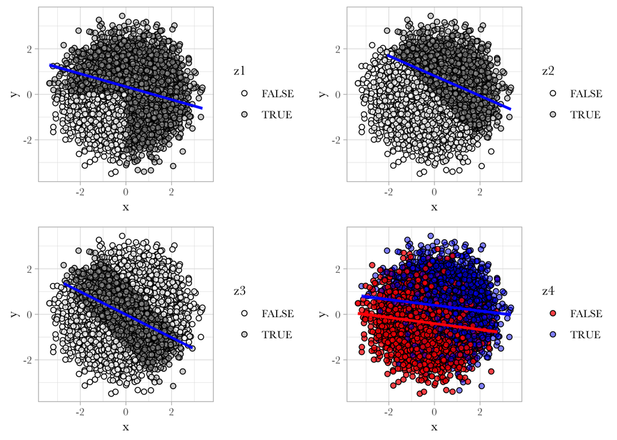

```r
grid.arrange(plot1, plot2, plot3, plot4)
```

### 4.1.6 Comparison of Coefficients

```r
mod0 <- lm(y ~ x, data = d)
mod1 <- lm(y ~ x, data = d |> filter(z1==TRUE))
mod2 <- lm(y ~ x, data = d |> filter(z2==TRUE))
mod3 <- lm(y ~ x, data = d |> filter(z3==TRUE))
mod4 <- lm(y ~ x + z4, data = d)

msummary(list(mod0, mod1, mod2, mod3, mod4),
         output = "gt",
         title = "Collider Problems",
         gof_omit = "IC|Adj|F|RMSE|Log") |>
  opt_table_font(font = "Baskerville")
```

Collider Problems

|  | (1) | (2) | (3) | (4) | (5) |
| --- | --- | --- | --- | --- | --- |
| (Intercept) | -0.002 | 0.336 | 0.815 | -0.014 | -0.407 |
|  | (0.010) | (0.011) | (0.013) | (0.008) | (0.013) |
| x | 0.015 | -0.285 | -0.441 | -0.503 | -0.129 |
|  | (0.010) | (0.011) | (0.013) | (0.010) | (0.010) |
| z4TRUE |  |  |  |  | 0.810 |
|  |  |  |  |  | (0.019) |
| Num.Obs. | 10000 | 7479 | 4938 | 7098 | 10000 |
| R2 | 0.000 | 0.082 | 0.195 | 0.253 | 0.147 |

It’s interesting to see how much the $\beta$ values for $X$ change based on conditioning for $Z_1$, $Z_2$, $Z_3$, and $Z_4$.

## Exercise 4.2

[output not shown]

## Exercise 4.3

> Provide an example of a treatment effect that you would expect to be highly heterogeneous, and explain why you think it is likely to be heterogeneous.

I suspect the treatment of an experimental drug on mental health (maybe on a scale from 0 to 10, 0 being absolute misery and 10 being absolute happiness) would be highly heterogeneous- namely because “mental health” is extremely variable to begin with. It would be difficult to isolate the effect of the drug on an individual’s mental health because so many things contribute to it: physical health, employment status & satisfaction, life satisfaction, social networks, strength of relationships, stress, and so on.

## Exercise 4.4

| Case | Age | Gender | Effect |
| --- | --- | --- | --- |
| A | 15 | Man | 7 |
| B | 40 | Woman | 3 |
| C | 30 | Woman | 7 |
| D | 20 | Non-binary | 8 |
| E | 15 | Man | 7 |
| F | 25 | Woman | 4 |

> a. What is the overall average treatment effect for the population?

```r
(7 + 3 + 7 + 8 + 7 + 4)/6
```

```
[1] 6
```

$\text{ATE} = 6$ for the population.

> b. What is the average treatment effect for Women?

```r
(3 + 7 + 4)/3
```

```
[1] 4.666667
```

$\text{ATE}_{women} = 4.67$

> c. If nearly all Non-binary people get treated, and about half of all Women get treated, and we control for the differences between Women and Non-binary people, what kind of treatment effect average will we get, and what can we say about the numerical estimate we’ll get?

This will get us a *variance-weighted treatment effect*. Since about half the women get treated, and nearly all non-binary people get treated, there is variance in who gets treated. Since half women get treated and half do not, the variance in treatment among women is .25 (0.5 * 0.5). Since nearly all non-binary people get treated, the variance in treatment among non-binary folks is very small (assuming probability that a non-binary person gets treated is 0.95, the variance in treatment is 0.95 * 0.05 = 0.0475).  
This estimate will weight the treatment effect *of those with greater variation in treatment* more heavily. This means that in the above example, the estimate will be closer to the treatment effect for women (since there is so little– in fact, almost no- variation in the treatment for non-binary folks).

> d. If we assume that, in the absence of treatment, everyone would have had the same outcome, and also only teenagers (19 or younger) ever receive treatment, and we compare treated people to control people, what kind of treatment effect average will we get, and what can we say about the numerical estimate we’ll get?

This will get us a *conditional average treatment effect-* the average will be calculated on the condition that an individual is a teenager. This estimate will be weighted towards those who meet the condition specified.

## Exercise 4.5

> Give an example where the average treatment effect on the treated would be more useful to consider than the overall average treatment effect, and explain why.

The ATT is more beneficial than the overall ATE in instances where the treatment is only intended to work for a particular subset of the population. Let’s say I wanted to find the effect of ‘flipped’ classrooms (where lecture is delivered at home, and class time is devoted to homework) on student outcomes. I wouldn’t really be interested in student outcomes in general. I’d want to focus in on those who receive treatment.

Or, to borrow from the book, if I’m testing a drug on its effects on the prevalence of prostate cancer, I wouldn’t want to look at the effect among the entire population, I’d just want to focus on the treatment group (ie people with prostates).

## Exercise 4.6

> Which of the following describes the average treatment effect of assigning treatment, whether or not treatment is actually received?
1. Local average treatment effect
2. Average treatment on the treated
3. *Intent-to-treat*
4. Variance-weighted average treatment effect

## Exercise 4.7

> Which of the following describes the average treatment effect of assigning treatment, whether or not treatment is actually received?
1. Local average treatment effect
2. Average treatment on the treated
3. *Intent-to-treat*
4. Variance-weighted average treatment effect

## Exercise 4.8

> Suppose you are conducting an experiment to see whether pricing cookies at $1.99 versus $2 affects the decision to purchase the cookies. The population of interest is all adults in the United States. You recruit people from your university to participate and randomize them to either see cookies priced as $1.99 or $2, then write down whether they purchased cookies. What kind of average treatment effect can you identify from this experiment?

This would be conditional average treatment effect- the condition is that all individuals sampled are in college (whether or not they received treatment).

## Exercise 4.9

> For each of the following identification strategies, what kind of treatment effect(s) is most likely to be identified?
1. *A randomized experiment using a representative sample*  
   ATE (Average Treatment Effect)
2. *True randomization within only a certain demographic group*  
   CATE (Conditional Average Treatment Effect)
3. *Closing back door paths connected to variation in treatment*  
   Variance-Weighted Average Treatment Effect
4. *Isolating the part of the variation in treatment variable that is driven by an exogenous variable*  
   Local Average Treatment Effect
5. *The control group is comparable to the treatment group, but treatment effects may be different across these groups*  
   Heterogeneous Treatment Effect